# picciano-assignment4

Andrew Picciano

11/20/2019

## 1 Build simulation of Cob-Web model

## 2 Plot first 50 prices

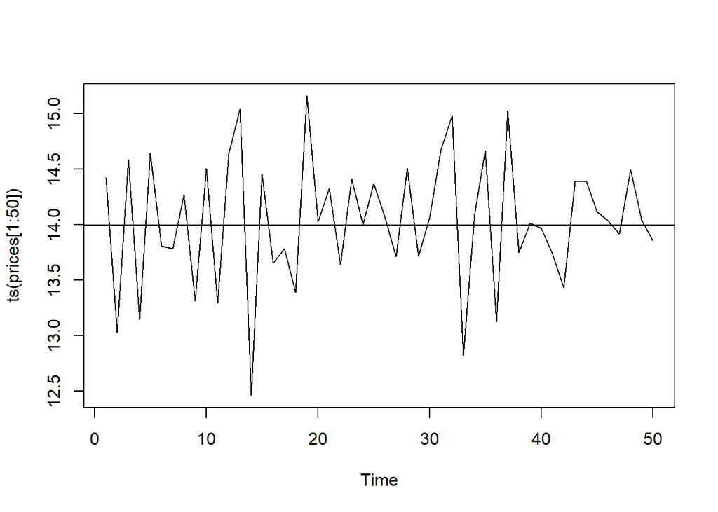

## 3 Generate both ACF and PACF functions. Describe patterns I see and explain why they occur. Use lag.max = 10.

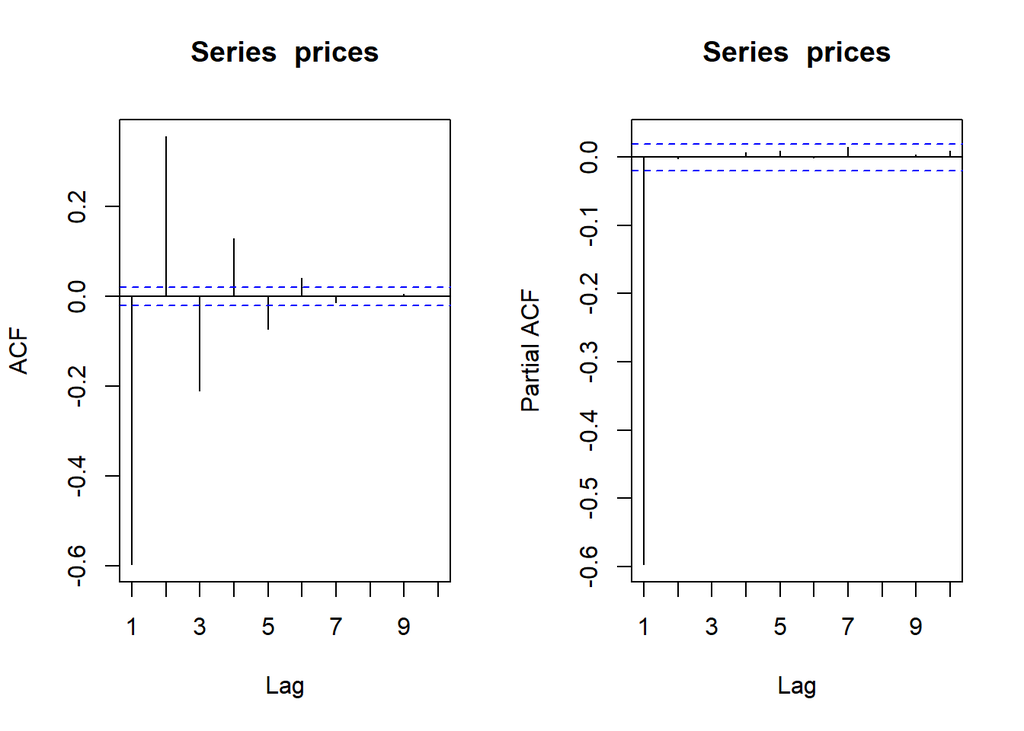

#### **Explanation**: The first time series difference *(t-1)* you see the phi of -0.6, and then successive periods, it reverts back to 0. This means the phi is getting less and less important. Also, since these are random variables the phi can go positive to negative across successive time lags. #### For PACF, the *(t-1)* time period is the only period it is concerned about, and all other periods have no impact on the previous lag, which is why those appear within the confidence interval.

## 4 Run linear regression of prices. Following below steps:

- Let generated prices be dependent variable and first lag be independent variable.
- What is the intercept? The intercept is 0 (slightly bigger than 0 but for purpose of analysis is 0).
- What is the slope? The slope is 1
- How do they relate to the parameters in the Cob-Web model? These relate to the Cob-Web model parameters by the fact the slope is perfectly correlated with the prior period *(t-1)*. This makes sense since the prior period is itself.

```
##
## Time series regression with "numeric" data:
## Start = 1, End = 9999
##
## Call:
## dynlm(formula = d1_prices ~ L(d1_prices, -1))
##
## Coefficients:
##      (Intercept)  L(d1_prices, -1)
##       -5.179e-22         1.000e+00
```

```
##
##  Box-Ljung test
##
## data:  d1_prices
## X-squared = 6370.7, df = 1, p-value < 2.2e-16
```

## 5 Load the oranges data set and create a ts() object of “Price_Oranges”. Note missing data in summer.

## 6 Plot the price of oranges and include mean in the graph

```
## Classes 'tbl_df', 'tbl' and 'data.frame':    143 obs. of  2 variables:
##  $ OBS          : chr  "1991M10" "1991M11" "1991M12" "1992M01" ...
##  $ Price_Oranges: num  19 16.8 16.1 14.3 14.6 13.5 13.5 14.5 18 NA ...
```

```
##   [1]  TRUE  TRUE  TRUE  TRUE  TRUE  TRUE  TRUE  TRUE  TRUE FALSE FALSE
##  [12] FALSE FALSE  TRUE  TRUE  TRUE  TRUE  TRUE  TRUE  TRUE  TRUE FALSE
##  [23] FALSE FALSE FALSE  TRUE  TRUE  TRUE  TRUE  TRUE  TRUE  TRUE  TRUE
##  [34] FALSE FALSE FALSE  TRUE  TRUE  TRUE  TRUE  TRUE  TRUE  TRUE  TRUE
##  [45]  TRUE FALSE FALSE FALSE FALSE  TRUE  TRUE  TRUE  TRUE  TRUE  TRUE
##  [56]  TRUE  TRUE FALSE FALSE FALSE FALSE  TRUE  TRUE  TRUE  TRUE  TRUE
##  [67]  TRUE  TRUE  TRUE FALSE FALSE FALSE  TRUE  TRUE  TRUE  TRUE  TRUE
##  [78]  TRUE  TRUE  TRUE  TRUE FALSE FALSE FALSE  TRUE  TRUE  TRUE  TRUE
##  [89]  TRUE  TRUE  TRUE  TRUE  TRUE FALSE FALSE FALSE FALSE  TRUE  TRUE
## [100]  TRUE  TRUE  TRUE  TRUE  TRUE  TRUE  TRUE FALSE FALSE  TRUE  TRUE
## [111]  TRUE  TRUE  TRUE  TRUE  TRUE  TRUE  TRUE FALSE FALSE FALSE  TRUE
## [122]  TRUE  TRUE  TRUE  TRUE  TRUE  TRUE  TRUE  TRUE FALSE FALSE FALSE
## [133]  TRUE  TRUE  TRUE  TRUE  TRUE  TRUE  TRUE  TRUE  TRUE FALSE FALSE
```

```
##   [1] 19.00 16.80 16.10 14.30 14.60 13.50 13.50 14.50 18.00 13.10 12.20
##  [12]  9.95 10.20  9.20  9.60 10.30 12.50 17.40 14.00 11.40 11.10 11.88
##  [23] 11.80 11.80 13.70 14.50 12.50 12.70 11.90 12.90 13.00 12.80 13.20
##  [34] 13.90 14.50 13.50 13.50 14.20 14.20 15.00 15.20 20.00 15.20 12.40
##  [45] 11.20 13.10 13.10 12.30 13.10 18.20 14.50 12.40 12.20 11.40 11.60
##  [56] 13.00 12.60 13.20 16.00 17.50 16.90 17.10 18.50 18.30 18.00 17.60
##  [67] 18.50 22.00 18.50 14.20 12.50 11.40 14.20 13.50 13.50 16.30 16.40
##  [78] 15.70 14.20 13.10 12.80 14.40 14.00 13.50 14.00 18.00 16.00 14.90
##  [89] 13.70 14.10 14.20 15.20 14.00 14.80 16.10 17.70 15.60 15.60 13.50
## [100] 14.00 15.10 13.50 13.50 20.00
```

| OBS | Price_Oranges |
| --- | --- |
| 1991M10 | 19.00 |
| 1991M11 | 16.80 |
| 1991M12 | 16.10 |
| 1992M01 | 14.30 |
| 1992M02 | 14.60 |
| 1992M03 | 13.50 |
| 1992M04 | 13.50 |
| 1992M05 | 14.50 |
| 1992M06 | 18.00 |
| 1992M11 | 13.10 |

[output cut: 94 more lines]

[output not shown]

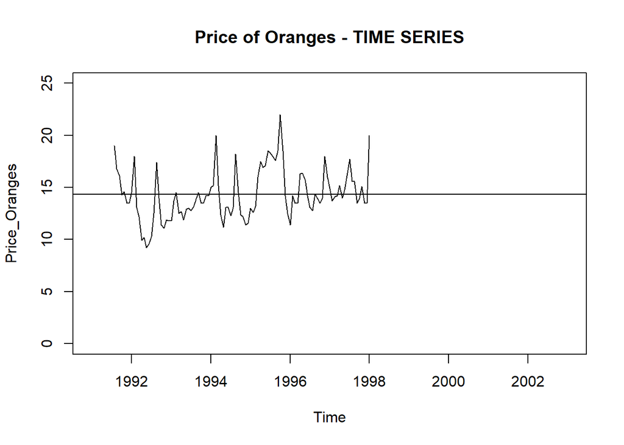

```
##  Time-Series [1:104, 1] from 1992 to 1998: 19 16.8 16.1 14.3 14.6 13.5 13.5 14.5 18 13.1 ...
##  - attr(*, "dimnames")=List of 2
##   ..$ : NULL
##   ..$ : chr "Price_Oranges"
```

## 7 Generate Acf and Pacf of the price of oranges. Describe differences between these plots and those from the simulation. Why do I think these differ?

- I believe these graphs differ from the previous graphs because the “shock” usually takes the rest of the growing season to get back to normal. A major weather impact (like a deep freeze or prolonged chill in Florida) can sustain prices over their moving average. Meaning there is typically only one shock in the season (if any), and then the prices return back to the mean of ~$14 once the weather goes back to normal and the market immediately picks up slack from the prior period. Once you are a few period away from the “shock” - typically when the weather returns to normal, the prices are close back to the mean. The Partial Autocorrelation Function (PACF) does not take the sustained seasonaility into account and expects the prices to revert faster to the mean since there is no theta (or memory) to the prior period.

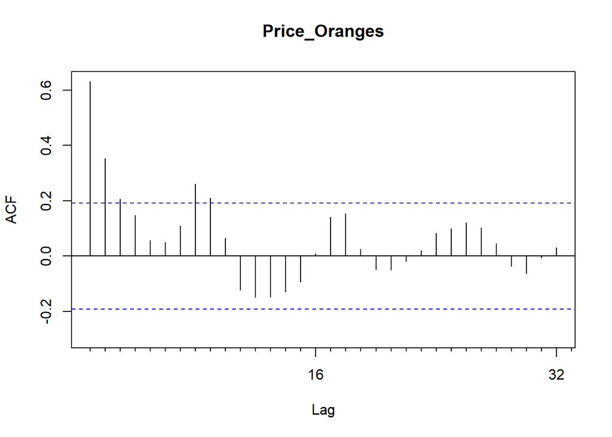

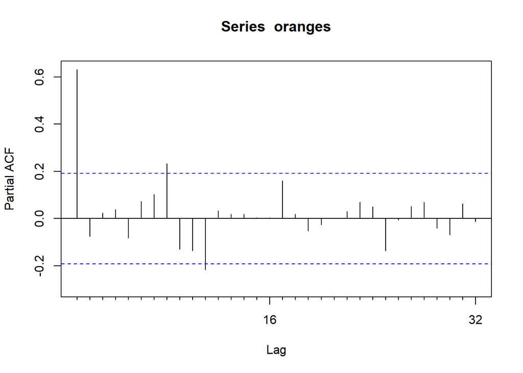

## 8 Run a regression of oranges against its lag. What is the suggested value of phi?

```
##
## Time series regression with "ts" data:
## Start = 1991(11), End = 1997(16)
##
## Call:
## dynlm(formula = d1_oranges ~ L(d1_oranges, -1))
##
## Coefficients:
##       (Intercept)  L(d1_oranges, -1)
##          -0.05326           -0.02115
```

## 9 Run original simulation with the value of phi that I have found.

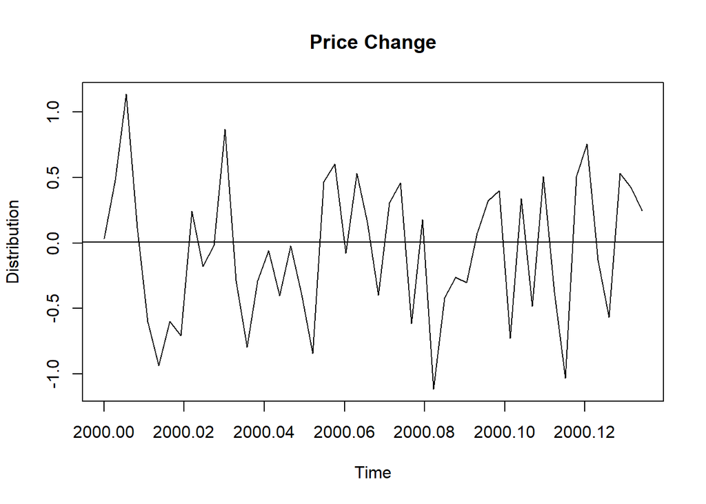

## 10 Does the series created fluctuate up and down more or less? Explain how positive value of phi changes simulation I carried out in 1?

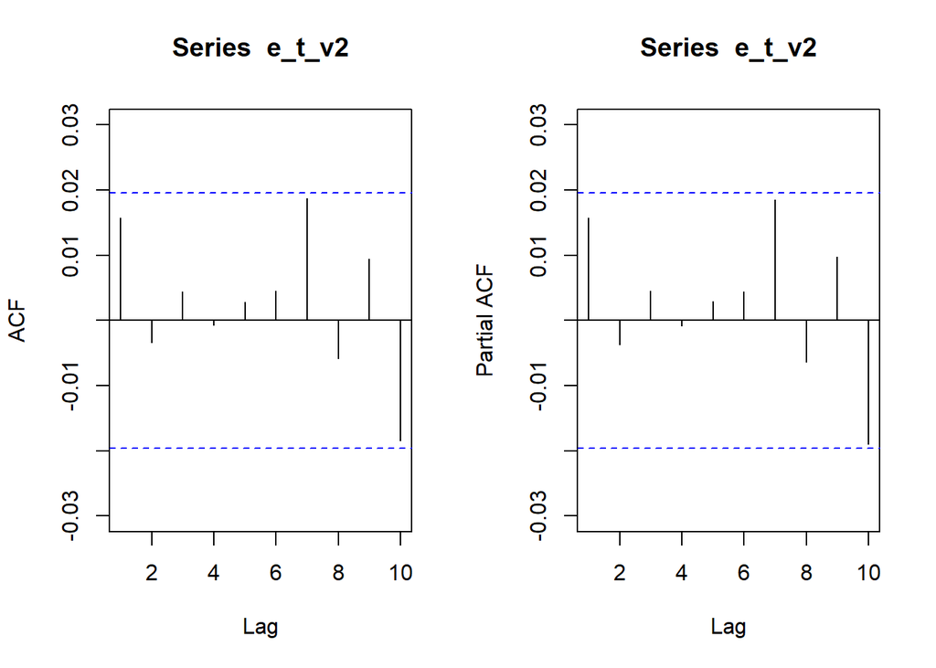